# MidTerm - KMeans

Murali Shanker

October 31, 2019

# Problem

The dataset on American College and University Rankings contains information on 1302 American colleges and universities offering an undergraduate program. For each university, there are 17 measurements, including continuous measurements (such as tuition and grad- uation rate) and categorical measurements (such as location by state and whether it is a private or public school).

Note that many records are missing some measurements.

1.Remove all records with missing measurements from the dataset. 2.For all the continuous measurements, run K-Means clustering. Make sure to normalize the measurements. How many clusters seem reasonable for describing these data? What was your optimal K? 3.Compare the summary statistics for each cluster and describe each cluster in this context (e.g., “Universities with high tuition, low acceptance rate…”). 4.Use the categorical measurements that were not used in the analysis (State and Private/Public) to characterize the different clusters. Is there any relationship between the clusters and the categorical information? 5.What other external information can explain the contents of some or all of these clusters? 6.Consider Tufts University, which is missing some information. Compute the Euclidean distance of this record from each of the clusters that you found above (using only the measurements that you have). Which cluster is it closest to? Impute the missing values for Tufts by taking the average of the cluster on those measurements. ***

## Read and Clean Data

```r
# load required packages
library(tidyverse)  # data manipulation
library(factoextra) # clustering algorithms & visualization
library(ISLR)
```

```r
# read data
univ <- read.csv("./Universities.csv")

# Standardize using all numeric data
univ.norm <- scale(univ[,-c(1:3)])
univ.norm <- cbind(univ[,1:3],univ.norm) # Public / Private is a categorical variable
univ.norm[,3] <- as.factor(univ.norm[,3])

# Extract the Tufts record
tuft.norm <- univ.norm[which(univ.norm$College.Name=="Tufts University"),]
tuft.norm
```

```
##         College.Name State Public..1...Private..2. X..appli..rec.d
## 476 Tufts University    MA                       2        1.372653
##     X..appl..accepted X..new.stud..enrolled X..new.stud..from.top.10.
## 476         0.7705108             0.4817205                  1.874556
##     X..new.stud..from.top.25. X..FT.undergrad X..PT.undergrad
## 476                  1.803047       0.1992003              NA
##     in.state.tuition out.of.state.tuition      room    board add..fees
## 476         2.207062             2.499321 0.4547283 1.313225 0.2364556
##     estim..book.costs estim..personal.. X..fac..w.PHD stud..fac..ratio
## 476         0.2989274        -0.6458426      1.702848       -0.8789855
##     Graduation.rate
## 476        1.672645
```

```r
# Now remove all recods with missing values

univ.norm <- na.omit(univ.norm)
summary(univ.norm)
```

```
##                    College.Name     State     Public..1...Private..2.
##  Trinity College         :  4   PA     : 42   1:128
##  Augustana College       :  2   NY     : 38   2:343
##  Monmouth College        :  2   OH     : 24
##  University of St. Thomas:  2   NC     : 23
##  Westminster College     :  2   MA     : 22
##  Adams State College     :  1   TX     : 20
##  (Other)                 :458   (Other):302
##  X..appli..rec.d   X..appl..accepted  X..new.stud..enrolled
##  Min.   :-0.7553   Min.   :-0.80399   Min.   :-0.849988
##  1st Qu.:-0.5506   1st Qu.:-0.54876   1st Qu.:-0.582063
##  Median :-0.3123   Median :-0.28597   Median :-0.379707
##  Mean   : 0.1116   Mean   : 0.08542   Mean   : 0.002062
##  3rd Qu.: 0.3134   3rd Qu.: 0.26004   3rd Qu.: 0.132967
##  Max.   :12.8013   Max.   :10.86662   Max.   : 6.345532
##
##  X..new.stud..from.top.10. X..new.stud..from.top.25. X..FT.undergrad
##  Min.   :-1.3473           Min.   :-2.07602          Min.   :-0.75771
##  1st Qu.:-0.5828           1st Qu.:-0.59144          1st Qu.:-0.58850
##  Median :-0.1459           Median : 0.07902          Median :-0.43514
##  Mean   : 0.1278           Mean   : 0.15812          Mean   :-0.02854
##  3rd Qu.: 0.5640           3rd Qu.: 0.79736          3rd Qu.: 0.07983
##  Max.   : 3.8404           Max.   : 2.28194          Max.   : 6.14989
##
##  X..PT.undergrad   in.state.tuition  out.of.state.tuition
##  Min.   :-0.6462   Min.   :-1.3629   Min.   :-1.9740
##  1st Qu.:-0.5980   1st Qu.:-0.7941   1st Qu.:-0.4764
##  Median :-0.4680   Median : 0.3666   Median : 0.1973
##  Mean   :-0.1699   Mean   : 0.2822   Mean   : 0.3113
##  3rd Qu.:-0.1271   3rd Qu.: 1.0001   3rd Qu.: 0.9612
##  Max.   :12.4115   Max.   : 2.2817   Max.   : 2.5950
##
##       room             board            add..fees
##  Min.   :-1.6290   Min.   :-2.31205   Min.   :-0.81387
##  1st Qu.:-0.6731   1st Qu.:-0.46995   1st Qu.:-0.54223
##  Median :-0.3690   Median : 0.03176   Median :-0.23864
##  Mean   :-0.2551   Mean   : 0.09212   Mean   :-0.02768
##  3rd Qu.: 0.1289   3rd Qu.: 0.54253   3rd Qu.: 0.20024
##  Max.   : 1.9997   Max.   : 3.74771   Max.   : 6.08247
##
##  estim..book.costs   estim..personal.. X..fac..w.PHD     stud..fac..ratio
##  Min.   :-2.748480   Min.   :-1.5951   Min.   :-3.4022   Min.   :-2.3058
##  1st Qu.:-0.298603   1st Qu.:-0.7550   1st Qu.:-0.3167   1st Qu.:-0.6862
##  Median :-0.298603   Median :-0.2650   Median : 0.4126   Median :-0.2813
##  Mean   :-0.007107   Mean   :-0.1083   Mean   : 0.2559   Mean   :-0.1728
##  3rd Qu.: 0.298927   3rd Qu.: 0.2950   3rd Qu.: 1.0297   3rd Qu.: 0.3068
##  Max.   :10.695964   Max.   : 7.5754   Max.   : 1.9272   Max.   : 2.6880
##
##  Graduation.rate
##  Min.   :-2.4038
##  1st Qu.:-0.3920
##  Median : 0.2962
##  Mean   : 0.2730
##  3rd Qu.: 0.9844
##  Max.   : 3.0491
##
```

## Determine K

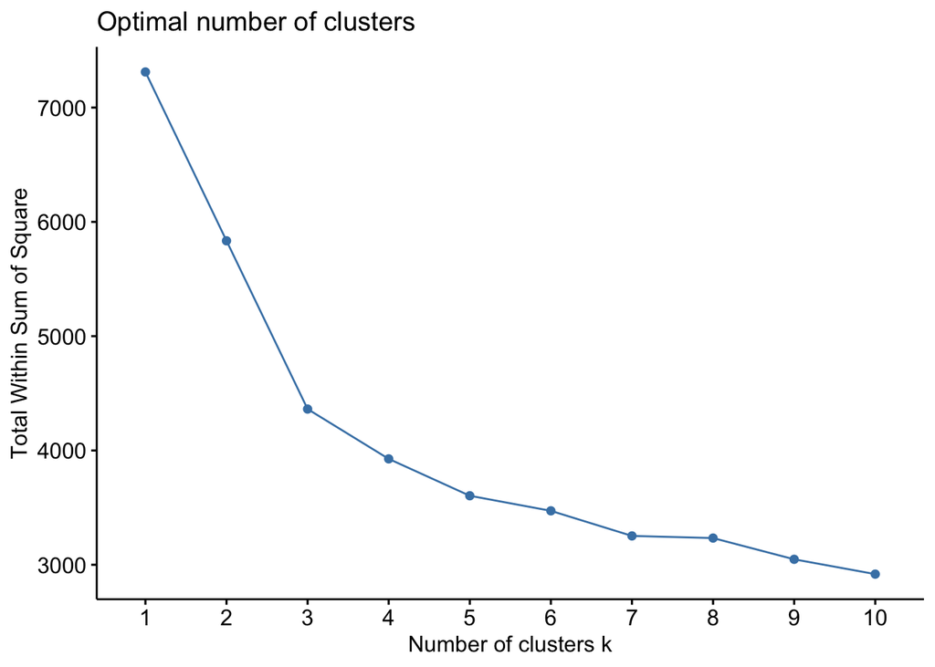

```r
fviz_nbclust(univ.norm[,-c(1:3)], kmeans, method = "wss")
```

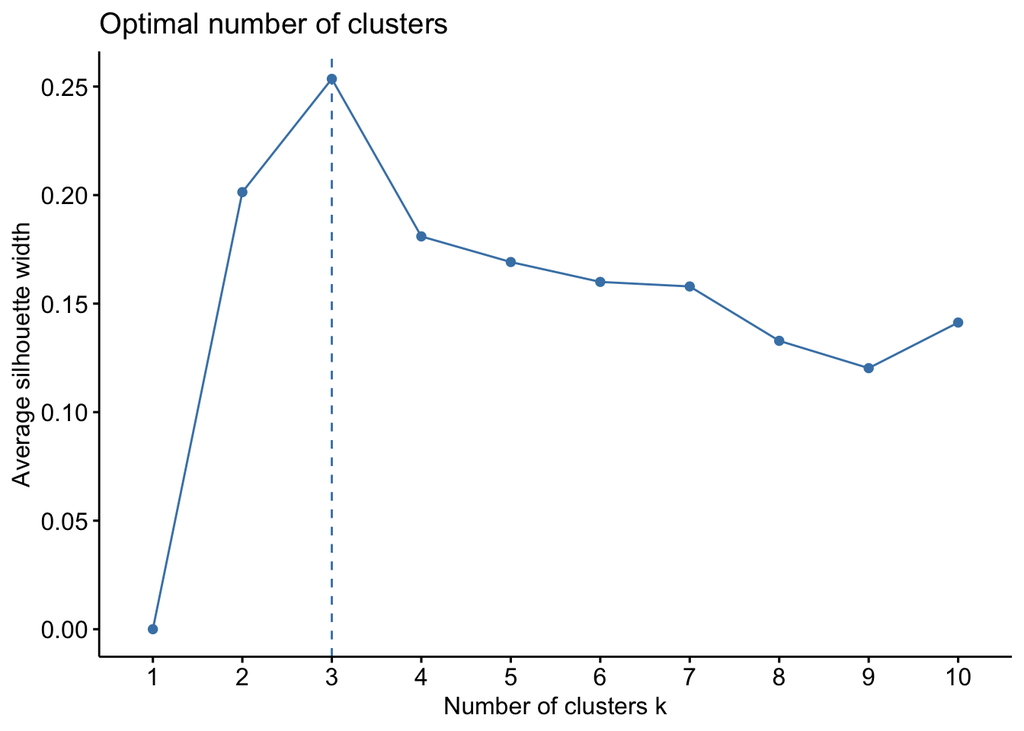

```r
fviz_nbclust(univ.norm[,-c(1:3)], kmeans, method = "silhouette")
```

It appears that the optimal number of clusters is 3.

## Explore clusters

```r
set.seed(120)
k3 <- kmeans(univ.norm[,-c(1:3)], centers = 3, nstart = 25)
univ.k3center <- as.data.frame(k3$centers)

colnames(univ.k3center) <- c("Recd","Accpt","newSe","newS10","newS25","FTu","PTu","INt","OSt","room","board","fees","books","personal","FPhD","SFRatio","GRate")

# Add a column for cluster number / to be also used for color
cluster <- matrix(c("1","2","3"),nrow = 3)
univ.k3center <- cbind(cluster,univ.k3center)
```

We will use GGally to draw parallel plots

```r
library(hrbrthemes)
library(GGally)
library(viridis)
```

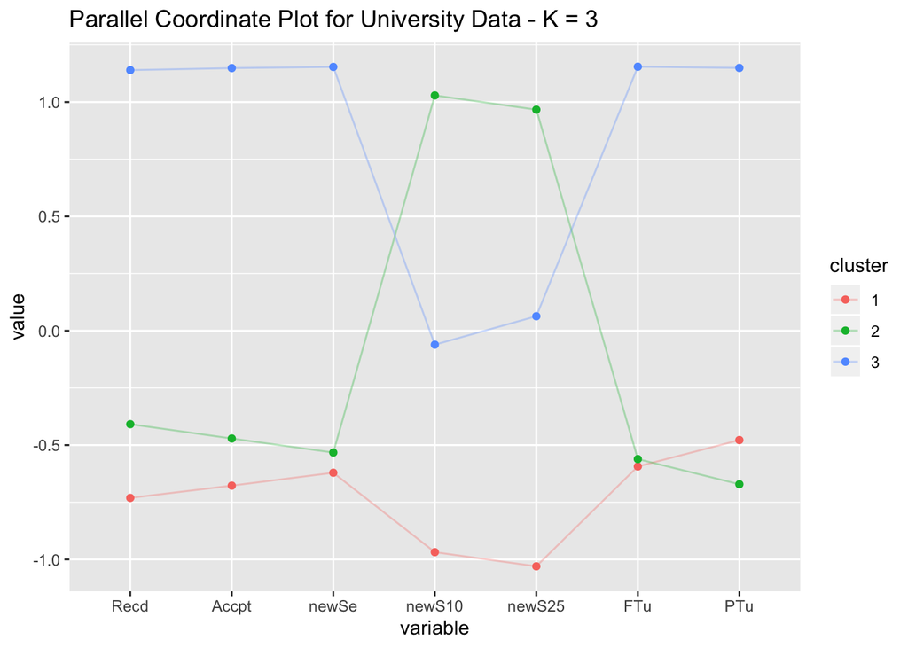

```r
# We write two parallel plots for clarity
ggparcoord(univ.k3center,
    columns = 2:8, groupColumn = 1,
    showPoints = TRUE,
    title = "Parallel Coordinate Plot for University Data - K = 3",
    alphaLines = 0.3
    )
```

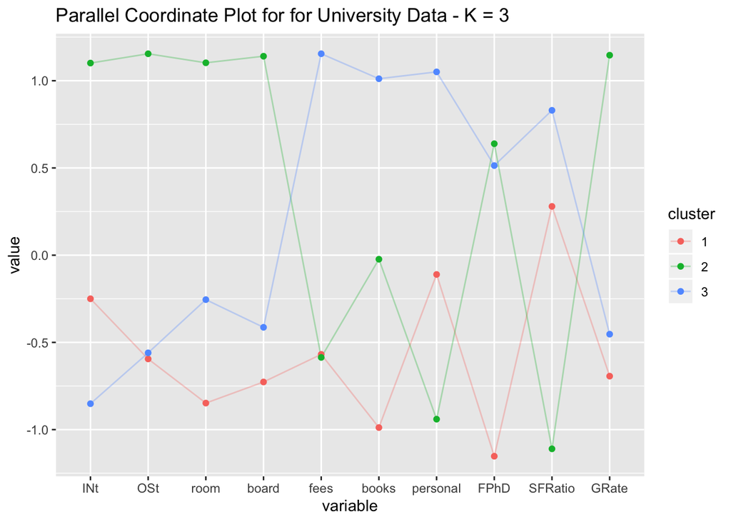

```r
ggparcoord(univ.k3center,
    columns = 9:18, groupColumn = 1,
    showPoints = TRUE,
    title = "Parallel Coordinate Plot for for University Data - K = 3",
    alphaLines = 0.3
    )
```

## Explore relationship

Here, we explore the relationship between the categorical variables and clusters

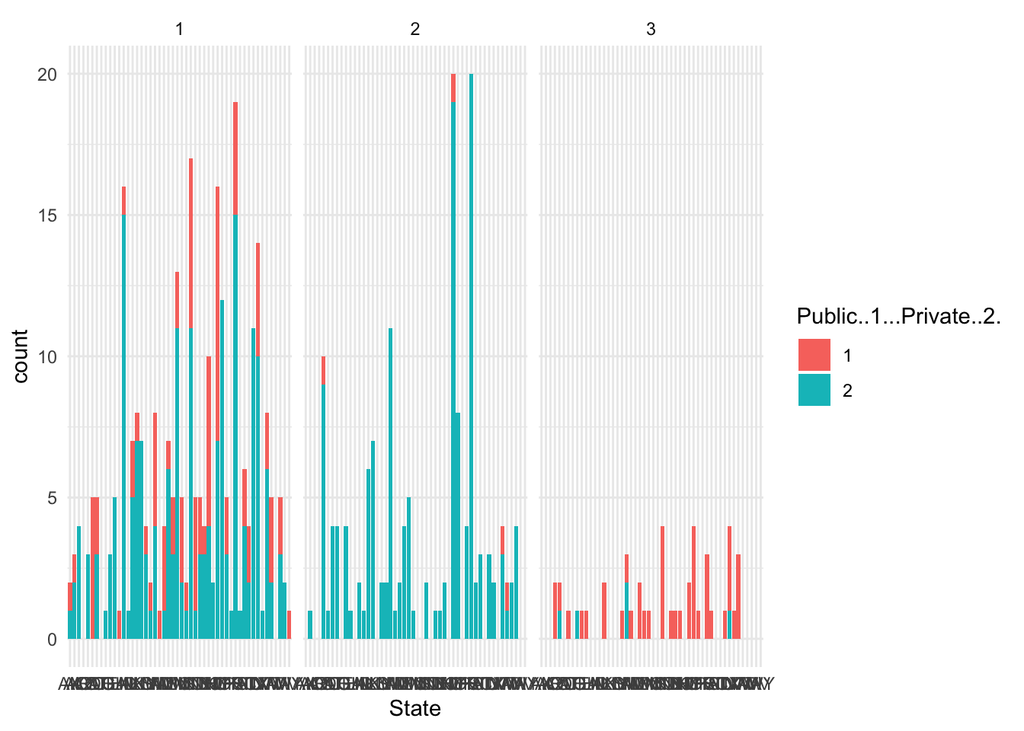

```r
library(ggplot2)

cls <- as.factor(k3$cluster) # Save the cluster values
ts <- cbind(cls,univ.norm[,1:3]) # combine with categorical data

ggplot(ts) +
 aes(x = State, fill = Public..1...Private..2.) +
 geom_bar() +
 scale_fill_hue() +
 theme_minimal() +
 facet_wrap(vars(cls))
```

A breakdown by State or Type of Institution (4-year versus 2-year, PhD granting versus not, etc.) might provide finer assessments to the clusters.

## Prediction for Tufts

```r
tuft.dist <- rbind(k3$centers,tuft.norm[,-c(1:3)])
get_dist(tuft.dist)
```

```
##            1        2        3
## 2   3.812258
## 3   6.215899 6.625461
## 476 6.452006 2.772901 6.848831
```

Clearly, the shortest distance for Tufts Univesity is Cluster 2. That aligns with our discussion that Cluster 2 mainly consists of private universities.

Now, we replace the missing values in our Tufts record with the cluster centroids from Cluster 2

```r
cl2 <- as.list(k3$centers[2,])
library(tidyr)
tuft.norm.rep <- replace_na(tuft.norm,cl2)
tuft.norm.rep
```

[output not shown]